# **Exploiratory Data Analysis on Depression, Anxiety and Stress**

> **Author:** PRIYAM SUR

> **Source:** https://openpsychometrics.org/tests/TMAS/

# **Introduction**

## About

> These are the results of an interactive version of the Taylor Manifest Anxiety Scale.  
> The Taylor Manifest Anxiety Scale was first developed in 1953 to identify individuals who would be good subjects for studies of stress and other related psychological phenomenon. Since then it has been used as a measure of anxiety as general personality trait. Anxiety is a complex psychological construct that includes a multiple of different facets related to extensive worrying that may impair normal functioning. The test has been widely studied and used in research however there are some concerns that it does not measure a single trait but instead measures a basket of loosely related ones and so the score is not that meaningful.

### Method

> This data was collected with an on-line version of the Depression Anxiety Stress Scales (DASS), see http://www2.psy.unsw.edu.au/dass/  
> The survey was open to anyone and people were motivated to take it to get personalized results. At the end of the test they also were given the option to complete a short research survey. This datatset comes from those who agreed to complete the research survey and answered yes to the question "Have you given accurate answers and may they be used for research?" at the end.  
> This data was collected 2017 - 2019.

## Description of Attributes

> The following items were included in the survey:  
> Q.01. I found myself getting upset by quite trivial things.  
> Q.02. I was aware of dryness of my mouth.  
> Q.03. I couldn't seem to experience any positive feeling at all.  
> Q.04. I experienced breathing difficulty (eg, excessively rapid breathing, breathlessness in the absence of physical exertion).  
> Q.05. I just couldn't seem to get going.  
> Q.06. I tended to over-react to situations.  
> Q.07. I had a feeling of shakiness (eg, legs going to give way).  
> Q.08. I found it difficult to relax.  
> Q.09. I found myself in situations that made me so anxious I was most relieved when they ended.  
> Q.10. I felt that I had nothing to look forward to.  
> Q.11. I found myself getting upset rather easily.  
> Q.12. I felt that I was using a lot of nervous energy.  
> Q.13. I felt sad and depressed.  
> Q.14. I found myself getting impatient when I was delayed in any way (eg, elevators, traffic lights, being kept waiting).  
> Q.15. I had a feeling of faintness.  
> Q.16. I felt that I had lost interest in just about everything.  
> Q.17. I felt I wasn't worth much as a person.  
> Q.18. I felt that I was rather touchy.  
> Q.19. I perspired noticeably (eg, hands sweaty) in the absence of high temperatures or physical exertion.  
> Q.20. I felt scared without any good reason.  
> Q.21. I felt that life wasn't worthwhile.  
> Q.22. I found it hard to wind down.  
> Q.23. I had difficulty in swallowing.  
> Q.24. I couldn't seem to get any enjoyment out of the things I did.  
> Q.25. I was aware of the action of my heart in the absence of physical exertion (eg, sense of heart rate increase, heart missing a beat).  
> Q.26. I felt down-hearted and blue.  
> Q.27. I found that I was very irritable.  
> Q.28. I felt I was close to panic.  
> Q.29. I found it hard to calm down after something upset me.  
> Q.30. I feared that I would be "thrown" by some trivial but unfamiliar task.  
> Q.31. I was unable to become enthusiastic about anything.  
> Q.32. I found it difficult to tolerate interruptions to what I was doing.  
> Q.33. I was in a state of nervous tension.  
> Q.34. I felt I was pretty worthless.  
> Q.35. I was intolerant of anything that kept me from getting on with what I was doing.  
> Q.36. I felt terrified.  
> Q.37. I could see nothing in the future to be hopeful about.  
> Q.38. I felt that life was meaningless.  
> Q.39. I found myself getting agitated.  
> Q.40. I was worried about situations in which I might panic and make a fool of myself.  
> Q.41. I experienced trembling (eg, in the hands).  
> Q.42. I found it difficult to work up the initiative to do things.  
> Each item was presented one at a time in a random order for each new participant along with a 4 point rating scale asking the user to indicate how often that had been true of them in the past week where  
> **1** = Did not apply to me at all  
> **2** = Applied to me to some degree, or some of the time  
> **3** = Applied to me to a considerable degree, or a good part of the time  
> **4** = Applied to me very much, or most of the time  
> (see the file demo1.png for how this looked)  
> This response is stored in variable A (e.g. Q01A). Also recorded was the time taken in milliseconds to answer that question (E) and that question's position in the survey (I).  
> These other durations were also recorded (measured on the server's side):  
> introelapse The time spent on the introduction/landing page (in seconds)  
> testelapse The time spent on all the DASS questions (should be equivalent to the time elapsed on all the indiviudal questions combined)  
> surveyelapse The time spent answering the rest of the demographic and survey questions  
> On the next page was a generic demographics survey with many different questions.

> The Ten Item Personality Inventory was administered (see Gosling, S. D., Rentfrow, P. J., & Swann, W. B., Jr. (2003). A Very Brief Measure of the Big Five Personality Domains. Journal of Research in Personality, 37, 504-528.):  
> TIPI01: Extraverted, enthusiastic.  
> TIPI02: Critical, quarrelsome.  
> TIPI03: Dependable, self-disciplined.  
> TIPI04: Anxious, easily upset.  
> TIPI05: Open to new experiences, complex.  
> TIPI06: Reserved, quiet.  
> TIPI07: Sympathetic, warm.  
> TIPI08: Disorganized, careless.  
> TIPI09: Calm, emotionally stable.  
> TIPI10: Conventional, uncreative.  
> The TIPI items were rated "I see myself as:" **_** such that  
> **1** = Disagree strongly  
> **2** = Disagree moderately  
> **3** = Disagree a little  
> **4** = Neither agree nor disagree  
> **5** = Agree a little  
> **6** = Agree moderately  
> **7** = Agree strongly

> The following items were presented as a check-list and subjects were instructed "In the grid below, check all the words whose definitions you are sure you know":  
> VCL01: boat  
> VCL02: incoherent  
> VCL03: pallid  
> VCL04: robot  
> VCL05: audible  
> VCL06: cuivocal  
> VCL07: paucity  
> VCL08: epistemology  
> VCL09: florted  
> VCL10: decide  
> VCL11: pastiche  
> VCL12: verdid  
> VCL13: abysmal  
> VCL14: lucid  
> VCL15: betray  
> VCL16: funny  
> **A value of 1 is checked, 0 means unchecked. The words at VCL6, VCL9, and VCL12 are not real words and can be used as a validity check.**

> A bunch more questions were then asked:
> 1. education

>    > "How much education have you completed?"

>    > > **1**=Less than high school  
>    > > **2**=High school  
>    > > **3**=University degree  
>    > > **4**=Graduate degree
> 2. urban

>    > "What type of area did you live when you were a child?"

>    > > **1**=Rural (country side)  
>    > > **2**=Suburban  
>    > > **3**=Urban (town, city)
> 3. gender

>    > "What is your gender?"

>    > > **1**=Male  
>    > > **2**=Female  
>    > > **3**=Other
> 4. engnat

>    > "Is English your native language?"

>    > > **1**=Yes  
>    > > **2**=No
> 5. age

>    > "How many years old are you?"
> 6. hand

>    > "What hand do you use to write with?"

>    > > **1**=Right  
>    > > **2**=Left  
>    > > **3**=Both
> 7. religion

>    > "What is your religion?"

>    > > **1**=Agnostic  
>    > > **2**=Atheist  
>    > > **3**=Buddhist  
>    > > **4**=Christian (Catholic)  
>    > > **5**=Christian (Mormon)  
>    > > **6**=Christian (Protestant)  
>    > > **7**=Christian (Other)  
>    > > **8**=Hindu  
>    > > **9**=Jewish  
>    > > **10**=Muslim  
>    > > **11**=Sikh  
>    > > **12**=Other
> 8. orientation

>    > "What is your sexual orientation?"

>    > > **1**=Heterosexual  
>    > > **2**=Bisexual  
>    > > **3**=Homosexual  
>    > > **4**=Asexual  
>    > > **5**=Other
> 9. race

>    > "What is your race?"

>    > > **10**=Asian  
>    > > **20**=Arab  
>    > > **30**=Black  
>    > > **40**=Indigenous Australian  
>    > > **50**=Native American  
>    > > **60**=White  
>    > > **70**=Other
> 10. voted

>     > "Have you voted in a national election in the past year?"

>     > > **1**=Yes  
>     > > **2**=No
> 11. married

>     > "What is your marital status?"

>     > > **1**=Never married  
>     > > **2**=Currently married  
>     > > **3**=Previously married
> 12. familysize

>     > "Including you, how many children did your mother have?"
> 13. major

>     > "If you attended a university, what was your major (e.g. "psychology", "English", "civil engineering")?"

> The following values were derived from technical information:
> 1. country

>    > ISO country code of where the user connected from
> 2. screensize

>    > Size of screen while attempting the survey

>    > > **1**=device with small screen (phone, etc)  
>    > > **2**=device with big screen (laptop, desktop, etc)
> 3. uniquenetworklocation

>    > Location of Network

>    > > **1**=only one survey from user's specific network in dataset  
>    > > **2**=multiple surveys submitted from the network of this user (2 does not necessarily imply duplicate records for an individual, as it could be different students at a single school or different memebers of the same household; and even if 1 there still could be duplicate records from a single individual e.g. if they took it once on their wifi and once on their phone)
> 4. source

>    > How the user found the test?

>    > > **1**=from the front page of the site hosting the survey  
>    > > **2**=from google  
>    > > **0**=other or unknown

> **References:**
> - [Open Psychometrics](https://openpsychometrics.org/tests/DASS/)
> - [Taylor, J. (1953). "A personality scale of manifest anxiety". The Journal of Abnormal and Social Psychology, 48(2), 285-290.](https://psycnet.apa.org/record/1954-02683-001)

```python
#Installing Libraries

!pip install numpy
!pip install pandas
!pip install matplotlib
!pip install seaborn
!pip install bioinfokit
```

```python
#Importing the installed libraries

import pandas as pd
import numpy as np
import matplotlib.pyplot as plt
import seaborn as sns
%matplotlib inline
import matplotlib
import bioinfokit
```

# **Importing Dataset**

```python
#Importing the Dataset

dataset = pd.read_csv('/DASS_data.csv')
print('Rows: {}, Columns: {}'.format(dataset.shape[0], dataset.shape[1]))
```

[output not shown]

```python
#Displaying the dataset

dataset
```

|  | Q01A | Q01I | Q01E | Q02A | Q02I | Q02E | Q03A | Q03I | Q03E | Q04A | Q04I | Q04E | Q05A | Q05I | Q50E | Q06A | Q06I | Q06E | Q07A | Q07I | Q07E | Q08A | Q08I | Q08E | Q09A | Q09I | Q09E | Q10A | Q10I | … |
| --- | --- | --- | --- | --- | --- | --- | --- | --- | --- | --- | --- | --- | --- | --- | --- | --- | --- | --- | --- | --- | --- | --- | --- | --- | --- | --- | --- | --- | --- | --- |
| 0 | 4 | 28 | 3890 | 4 | 25 | 2122 | 2 | 16 | 1944 | 4 | 8 | 2044 | 4 | 34 | 2153 | 4 | 33 | 2416 | 4 | 10 | 2818 | 4 | 13 | 2259 | 2 | 21 | 5541 | 1 | 38 | … |
| 1 | 4 | 2 | 8118 | 1 | 36 | 2890 | 2 | 35 | 4777 | 3 | 28 | 3090 | 4 | 10 | 5078 | 4 | 40 | 2790 | 3 | 18 | 3408 | 4 | 1 | 8342 | 3 | 37 | 916 | 2 | 32 | … |
| 2 | 3 | 7 | 5784 | 1 | 33 | 4373 | 4 | 41 | 3242 | 1 | 13 | 6470 | 4 | 11 | 3927 | 3 | 9 | 3704 | 1 | 17 | 4550 | 3 | 5 | 3021 | 2 | 32 | 5864 | 4 | 21 | … |
| 3 | 2 | 23 | 5081 | 3 | 11 | 6837 | 2 | 37 | 5521 | 1 | 27 | 4556 | 3 | 28 | 3269 | 3 | 26 | 3231 | 4 | 2 | 7138 | 2 | 19 | 3079 | 3 | 31 | 9650 | 3 | 17 | … |
| 4 | 2 | 36 | 3215 | 2 | 13 | 7731 | 3 | 5 | 4156 | 4 | 10 | 2802 | 4 | 2 | 5628 | 2 | 9 | 6522 | 4 | 34 | 2374 | 4 | 11 | 3054 | 4 | 7 | 2975 | 3 | 14 | … |
| ... | ... | ... | ... | ... | ... | ... | ... | ... | ... | ... | ... | ... | ... | ... | ... | ... | ... | ... | ... | ... | ... | ... | ... | ... | ... | ... | ... | ... | ... | … |
| 39769 | 2 | 31 | 3287 | 1 | 5 | 2216 | 3 | 29 | 3895 | 2 | 37 | 2767 | 3 | 39 | 1745 | 2 | 4 | 6424 | 1 | 36 | 3737 | 3 | 24 | 1977 | 1 | 18 | 4089 | 4 | 34 | … |
| 39770 | 3 | 14 | 4792 | 4 | 41 | 2604 | 3 | 15 | 2668 | 4 | 33 | 4609 | 3 | 17 | 2434 | 4 | 26 | 2503 | 4 | 34 | 2598 | 4 | 11 | 2133 | 3 | 13 | 10455 | 4 | 37 | … |
| 39771 | 2 | 1 | 25147 | 1 | 4 | 4555 | 2 | 14 | 3388 | 1 | 27 | 2753 | 1 | 6 | 5455 | 1 | 41 | 4938 | 1 | 24 | 3738 | 1 | 40 | 3820 | 2 | 28 | 10008 | 1 | 38 | … |
| 39772 | 3 | 36 | 4286 | 1 | 34 | 2736 | 2 | 10 | 5968 | 2 | 20 | 5655 | 3 | 9 | 2296 | 3 | 16 | 2627 | 3 | 32 | 3143 | 4 | 2 | 3164 | 3 | 19 | 5568 | 1 | 41 | … |
| 39773 | 2 | 28 | 32251 | 1 | 22 | 3317 | 2 | 4 | 11734 | 1 | 19 | 4659 | 4 | 32 | 4236 | 2 | 1 | 33800 | 1 | 3 | 7855 | 1 | 34 | 3151 | 1 | 31 | 12698 | 1 | 41 | … |

39774 rows × 172 columns

# **Data Cleaning**

## Removing rows with too many wrong answers

> A value of 1 is checked, 0 means unchecked.  
> The words:-

> > VCL06 - cuivocal  
> > VCL09 - florted  
> > VCL12 - verdid

> are not real words and can be used as a validity check.

```python
dataset['strike'] = 0
dataset['strike'] = dataset['strike'].where(dataset['VCL06']== 0, dataset['strike'] + 1)
dataset['strike'] = dataset['strike'].where(dataset['VCL09']== 0, dataset['strike'] + 1)
dataset['strike'] = dataset['strike'].where(dataset['VCL12']== 0, dataset['strike'] + 1)

dataset.strike.value_counts()
```

```
0    34582
1     4044
2      822
3      326
Name: strike, dtype: int64
```

```python
dataset = dataset.loc[~dataset['strike'].isin([2, 3])]
dataset.head(2)
```

|  | Q01A | Q01I | Q01E | Q02A | Q02I | Q02E | Q03A | Q03I | Q03E | Q04A | Q04I | Q04E | Q05A | Q05I | Q50E | Q06A | Q06I | Q06E | Q07A | Q07I | Q07E | Q08A | Q08I | Q08E | Q09A | Q09I | Q09E | Q10A | Q10I | … |
| --- | --- | --- | --- | --- | --- | --- | --- | --- | --- | --- | --- | --- | --- | --- | --- | --- | --- | --- | --- | --- | --- | --- | --- | --- | --- | --- | --- | --- | --- | --- |
| 0 | 4 | 28 | 3890 | 4 | 25 | 2122 | 2 | 16 | 1944 | 4 | 8 | 2044 | 4 | 34 | 2153 | 4 | 33 | 2416 | 4 | 10 | 2818 | 4 | 13 | 2259 | 2 | 21 | 5541 | 1 | 38 | … |
| 1 | 4 | 2 | 8118 | 1 | 36 | 2890 | 2 | 35 | 4777 | 3 | 28 | 3090 | 4 | 10 | 5078 | 4 | 40 | 2790 | 3 | 18 | 3408 | 4 | 1 | 8342 | 3 | 37 | 916 | 2 | 32 | … |

2 rows × 173 columns

```python
print('Rows: {}, Columns: {}'.format(dataset.shape[0], dataset.shape[1]))
```

[output not shown]

In some continous variables (in particular, test and survey time), extreme values appear occasionally, distorting the mean of the column. There are also some suspicious values that seem impossible to happen in practice (EG: Age above 120, number of children above 30)

## Removing rows for people who took the survey too quickly or slowly

```python
#Keeping Test Elapse data within the range of 95% Confidence Level
dataset = dataset[dataset['testelapse'] <= dataset['testelapse'].quantile(0.975)]
dataset = dataset[dataset['testelapse'] >= dataset['testelapse'].quantile(0.025)]

#Keeping Survey Elapse data within the range of 95% Confidence Level
dataset = dataset[dataset['surveyelapse'] <= dataset['surveyelapse'].quantile(0.975)]
dataset = dataset[dataset['surveyelapse'] >= dataset['surveyelapse'].quantile(0.025)]
```

## Replacing extreme ages with median

```python
median = dataset.loc[dataset['age'] <=80, 'age'].median()
dataset.loc[dataset.age > 80, 'age'] = np.nan
dataset.fillna(median,inplace=True)
```

## Removing unneeded columns

VCL columns is used to validating the consistency of user answers. Since we have already used it, they have served their purpose and we don't need it.

```python
vcls = dataset.iloc[:, -32:-16].columns
dataset = dataset.drop(columns= vcls )
dataset.head(2)
```

|  | Q01A | Q01I | Q01E | Q02A | Q02I | Q02E | Q03A | Q03I | Q03E | Q04A | Q04I | Q04E | Q05A | Q05I | Q50E | Q06A | Q06I | Q06E | Q07A | Q07I | Q07E | Q08A | Q08I | Q08E | Q09A | Q09I | Q09E | Q10A | Q10I | … |
| --- | --- | --- | --- | --- | --- | --- | --- | --- | --- | --- | --- | --- | --- | --- | --- | --- | --- | --- | --- | --- | --- | --- | --- | --- | --- | --- | --- | --- | --- | --- |
| 0 | 4 | 28 | 3890 | 4 | 25 | 2122 | 2 | 16 | 1944 | 4 | 8 | 2044 | 4 | 34 | 2153 | 4 | 33 | 2416 | 4 | 10 | 2818 | 4 | 13 | 2259 | 2 | 21 | 5541 | 1 | 38 | … |
| 1 | 4 | 2 | 8118 | 1 | 36 | 2890 | 2 | 35 | 4777 | 3 | 28 | 3090 | 4 | 10 | 5078 | 4 | 40 | 2790 | 3 | 18 | 3408 | 4 | 1 | 8342 | 3 | 37 | 916 | 2 | 32 | … |

2 rows × 157 columns

## Creating bin groups for age

Age variable is originally continous. However, creating bin groups transform it into ordinal data which makes is simpler to classify groups.

```python
age_group = [
    'below 20',
    '20 to 24',
    '25 to 29',
    '30 to 34',
    '35 to 39',
    '40 to 49',
    '50 to 59',
    'above 60',
]

def label_age(row):
    if row['age'] < 20:
        return age_group[0]
    elif row['age'] < 25:
        return age_group[1]
    elif row['age'] < 30:
        return age_group[2]
    elif row['age'] < 35:
        return age_group[3]
    elif row['age'] < 40:
        return age_group[4]
    elif row['age'] < 50:
        return age_group[5]
    elif row['age'] < 60:
        return age_group[6]
    elif row['age'] > 60:
        return age_group[7]

dataset['age_group'] = dataset.apply(lambda row: label_age(row), axis=1)
dataset.head(2)
```

|  | Q01A | Q01I | Q01E | Q02A | Q02I | Q02E | Q03A | Q03I | Q03E | Q04A | Q04I | Q04E | Q05A | Q05I | Q50E | Q06A | Q06I | Q06E | Q07A | Q07I | Q07E | Q08A | Q08I | Q08E | Q09A | Q09I | Q09E | Q10A | Q10I | … |
| --- | --- | --- | --- | --- | --- | --- | --- | --- | --- | --- | --- | --- | --- | --- | --- | --- | --- | --- | --- | --- | --- | --- | --- | --- | --- | --- | --- | --- | --- | --- |
| 0 | 4 | 28 | 3890 | 4 | 25 | 2122 | 2 | 16 | 1944 | 4 | 8 | 2044 | 4 | 34 | 2153 | 4 | 33 | 2416 | 4 | 10 | 2818 | 4 | 13 | 2259 | 2 | 21 | 5541 | 1 | 38 | … |
| 1 | 4 | 2 | 8118 | 1 | 36 | 2890 | 2 | 35 | 4777 | 3 | 28 | 3090 | 4 | 10 | 5078 | 4 | 40 | 2790 | 3 | 18 | 3408 | 4 | 1 | 8342 | 3 | 37 | 916 | 2 | 32 | … |

2 rows × 158 columns

```python
dataset.info()
```

```
<class 'pandas.core.frame.DataFrame'>
Int64Index: 34941 entries, 0 to 39773
Columns: 158 entries, Q01A to age_group
dtypes: float64(1), int64(154), object(3)
memory usage: 42.4+ MB
```

# **Response, Position and Time Taken**

## Rearranging Response, Position and Time Taken Columns

```python
#creating a dataframe of column list of responses of the question for the purpose of later use

response_c = []

for i in range(0, 42*3, 3):
    response_c.append(dataset.columns[i])


#Creating list of mean values of response, position and time of all the questions

Response = []
Position = []
Time = []

for i in range(0, 42*3, 3):
    Response.append(dataset[dataset.columns[i]].mean())

for i in range(0, 42*3, 3):
    Position.append(dataset[dataset.columns[i+1]].mean())

for i in range(0, 42*3, 3):
    Time.append(dataset[dataset.columns[i+2]].mean())
```

## Creating a Table of these three columns

```python
#Creating a dataframe of response, position and time of all the questions

Questions = pd.DataFrame({'Response':Response, 'Position':Position, 'Time':Time}, index=range(1,43))
Questions.index.name = 'Q.No.'
Questions
```

| Q.No. | Response | Position | Time |
| --- | --- | --- | --- |
| 1 | 2.613033 | 21.560659 | 5816.304055 |
| 2 | 2.168427 | 21.222003 | 4941.945193 |
| 3 | 2.208323 | 21.572479 | 5781.113591 |
| 4 | 1.929166 | 21.460347 | 5951.185742 |
| 5 | 2.501445 | 21.521336 | 5000.921897 |
| 6 | 2.529264 | 21.543087 | 4888.540740 |
| 7 | 1.903924 | 21.474543 | 5289.680919 |
| 8 | 2.457314 | 21.538279 | 4140.688503 |
| 9 | 2.662517 | 21.589851 | 9033.068287 |
| 10 | 2.432873 | 21.433044 | 5039.802353 |
| 11 | 2.800836 | 21.477977 | 4692.683552 |
| 12 | 2.406342 | 21.498669 | 5277.629747 |
| 13 | 2.769955 | 21.512607 | 3663.706105 |
| 14 | 2.575026 | 21.566441 | 7527.030308 |
| 15 | 1.805529 | 21.534301 | 4726.605964 |
| 16 | 2.505910 | 21.467159 | 5247.419994 |
| 17 | 2.647692 | 21.483672 | 4730.540740 |
| 18 | 2.468390 | 21.492745 | 5452.277525 |
| 19 | 1.928537 | 21.507255 | 7701.510174 |
| 20 | 2.312384 | 21.526373 | 4645.761369 |
| 21 | 2.329699 | 21.574425 | 4409.545634 |
| 22 | 2.320769 | 21.500415 | 5988.665779 |
| 23 | 1.539824 | 21.473598 | 4387.770814 |
| 24 | 2.419679 | 21.582754 | 6061.743711 |
| 25 | 2.168341 | 21.560917 | 9268.944134 |
| 26 | 2.643141 | 21.449615 | 4648.708137 |
| 27 | 2.600441 | 21.552417 | 5224.011076 |
| 28 | 2.193698 | 21.529493 | 4005.091554 |
| 29 | 2.643914 | 21.457257 | 5642.342577 |
| 30 | 2.383904 | 21.453307 | 8029.017916 |
| 31 | 2.360207 | 21.477090 | 6411.783006 |
| 32 | 2.433703 | 21.349217 | 7617.400704 |
| 33 | 2.390973 | 21.412495 | 4645.455310 |
| 34 | 2.621877 | 21.519991 | 4019.905355 |
| 35 | 2.287714 | 21.582267 | 10490.865745 |
| 36 | 2.258235 | 21.408775 | 3933.756017 |
| 37 | 2.358805 | 21.571764 | 5854.105635 |
| 38 | 2.374031 | 21.564924 | 3955.884033 |
| 39 | 2.429953 | 21.563321 | 6944.723391 |
| 40 | 2.645631 | 21.505939 | 6774.456198 |
| 41 | 1.943390 | 21.465613 | 4825.799433 |
| 42 | 2.661286 | 21.461578 | 6772.819782 |

## Descriptive Statistics of Response

```python
#Descriptive Statistics of column 'Response' of Questions dataframe

Questions['Response'].describe()
```

```
count    42.000000
mean      2.372288
std       0.274628
min       1.539824
25%       2.265605
50%       2.413011
75%       2.594087
max       2.800836
Name: Response, dtype: float64
```

Questions with significantly low response values

```python
#Displaying questions with less response values

Questions[Questions['Response'] < 2]
```

| Q.No. | Response | Position | Time |
| --- | --- | --- | --- |
| 4 | 1.929166 | 21.460347 | 5951.185742 |
| 7 | 1.903924 | 21.474543 | 5289.680919 |
| 15 | 1.805529 | 21.534301 | 4726.605964 |
| 19 | 1.928537 | 21.507255 | 7701.510174 |
| 23 | 1.539824 | 21.473598 | 4387.770814 |
| 41 | 1.943390 | 21.465613 | 4825.799433 |

From the above graph, average position of questions is almost same for all. Questions are placed randomly for each person.

```python
#Displaying questions with high response time

Questions[Questions['Time'] > 10000]
```

| Q.No. | Response | Position | Time |
| --- | --- | --- | --- |
| 35 | 2.287714 | 21.582267 | 10490.865745 |

## Data Visualisation

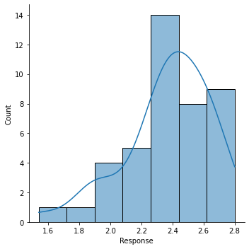

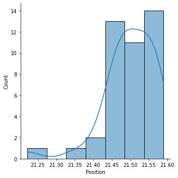

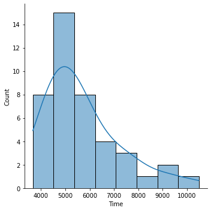

```python
#KDE Plot: Distribution Plot for all the attributes of the 'Questions' dataframe

plt.figure(figsize=(20,6))
sns.displot(data=Questions, x='Response', kde=True)
sns.displot(data=Questions, x='Position', kde=True)
sns.displot(data=Questions, x='Time', kde=True)
plt.tight_layout()
```

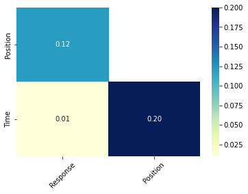

```python
#Displaying the Correlation Map among the attributes of Questions
#Purpose: To find if there's any strong relationship between any two attributes

ax = plt.axes()
ax.set(facecolor = 'white')

corr = Questions.corr().iloc[1:,:-1].copy()
mask = np.triu(np.ones_like(Questions.corr(), dtype = np.bool))
mask = mask[1:,:-1]

sns.heatmap(corr, mask = mask, cmap = 'YlGnBu', annot = True, fmt = "0.2f")

plt.xticks(rotation = 45)
plt.show()
```

**Conclusion:**

1. No Correlation among them
2. No Linear Relation in the Scatter Plot

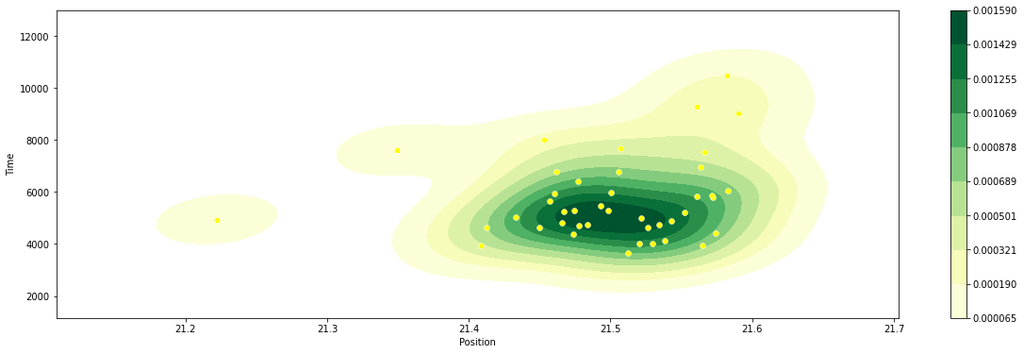

```python
#Scatter Plot between Positon and Time

plt.figure(figsize=(20,6))
sns.kdeplot(x = Questions['Position'], y = Questions['Time'], shade = True, cmap='YlGn', clip = (0,230000), cbar = True)
sns.scatterplot(data=Questions, x='Position', y='Time', color = 'yellow')
plt.show()
```

# **TIPI**

## Creating a Table for TIPI Columns

```python
#TIPI DATASET

tipi = dataset.iloc[:, 131:141]
tipi
```

|  | TIPI01 | TIPI02 | TIPI03 | TIPI04 | TIPI05 | TIPI06 | TIPI07 | TIPI08 | TIPI09 | TIPI10 |
| --- | --- | --- | --- | --- | --- | --- | --- | --- | --- | --- |
| 0 | 1 | 5 | 7 | 7 | 7 | 7 | 7 | 5 | 1 | 1 |
| 1 | 6 | 5 | 4 | 7 | 5 | 4 | 7 | 7 | 1 | 5 |
| 2 | 2 | 5 | 2 | 2 | 5 | 6 | 5 | 5 | 3 | 2 |
| 3 | 1 | 1 | 7 | 4 | 6 | 4 | 6 | 1 | 6 | 1 |
| 4 | 2 | 5 | 3 | 6 | 5 | 5 | 5 | 6 | 3 | 3 |
| ... | ... | ... | ... | ... | ... | ... | ... | ... | ... | ... |
| 39768 | 6 | 5 | 4 | 5 | 6 | 3 | 5 | 2 | 5 | 7 |
| 39770 | 4 | 5 | 5 | 7 | 4 | 6 | 4 | 7 | 4 | 4 |
| 39771 | 6 | 6 | 7 | 5 | 6 | 3 | 6 | 1 | 5 | 4 |
| 39772 | 1 | 6 | 5 | 7 | 3 | 5 | 3 | 5 | 3 | 4 |
| 39773 | 6 | 2 | 3 | 5 | 6 | 3 | 5 | 5 | 1 | 2 |

34941 rows × 10 columns

## Descriptive Statistics of TIPI Table

```python
#Calculating mean of all the responses in TIPI data

tipi.mean(axis=0)
```

```
TIPI01    3.802725
TIPI02    4.192210
TIPI03    4.748977
TIPI04    5.172691
TIPI05    4.927764
TIPI06    4.850290
TIPI07    5.289803
TIPI08    4.280645
TIPI09    3.665522
TIPI10    3.772617
dtype: float64
```

## Adding Mean Response values in TIPI table

```python
#Calculating mean response of all the participants who took the survey
#Calculated mean response of all the participants are stored in a new dataframe 'qr'

qr = dataset[response_c].mean(axis=1)
qr
```

```
0        3.404762
1        2.619048
2        2.619048
3        2.166667
4        3.404762
           ...
39768    2.571429
39770    3.523810
39771    1.238095
39772    2.476190
39773    2.261905
Length: 34941, dtype: float64
```

```python
#Inserting mean response value of each survey takers in the first columns shifting other columns right hand side by one place

tipi.insert(0, 'response', qr.values)
tipi
```

|  | response | TIPI01 | TIPI02 | TIPI03 | TIPI04 | TIPI05 | TIPI06 | TIPI07 | TIPI08 | TIPI09 | TIPI10 |
| --- | --- | --- | --- | --- | --- | --- | --- | --- | --- | --- | --- |
| 0 | 3.404762 | 1 | 5 | 7 | 7 | 7 | 7 | 7 | 5 | 1 | 1 |
| 1 | 2.619048 | 6 | 5 | 4 | 7 | 5 | 4 | 7 | 7 | 1 | 5 |
| 2 | 2.619048 | 2 | 5 | 2 | 2 | 5 | 6 | 5 | 5 | 3 | 2 |
| 3 | 2.166667 | 1 | 1 | 7 | 4 | 6 | 4 | 6 | 1 | 6 | 1 |
| 4 | 3.404762 | 2 | 5 | 3 | 6 | 5 | 5 | 5 | 6 | 3 | 3 |
| ... | ... | ... | ... | ... | ... | ... | ... | ... | ... | ... | ... |
| 39768 | 2.571429 | 6 | 5 | 4 | 5 | 6 | 3 | 5 | 2 | 5 | 7 |
| 39770 | 3.523810 | 4 | 5 | 5 | 7 | 4 | 6 | 4 | 7 | 4 | 4 |
| 39771 | 1.238095 | 6 | 6 | 7 | 5 | 6 | 3 | 6 | 1 | 5 | 4 |
| 39772 | 2.476190 | 1 | 6 | 5 | 7 | 3 | 5 | 3 | 5 | 3 | 4 |
| 39773 | 2.261905 | 6 | 2 | 3 | 5 | 6 | 3 | 5 | 5 | 1 | 2 |

34941 rows × 11 columns

## Data Visualisation of TIPI Table

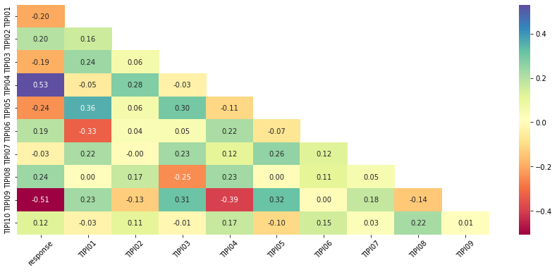

```python
#Correlation Matrix to find out if there's any strong relationship between Response and TIPI attributes

plt.figure(figsize=(15,6))

ax = plt.axes()
ax.set(facecolor = 'white')

corr = tipi.corr().iloc[1:,:-1].copy()
mask = np.triu(np.ones_like(tipi.corr(), dtype = np.bool))
mask = mask[1:,:-1]

sns.heatmap(corr, mask = mask, cmap = 'Spectral', annot = True, fmt = "0.2f")

plt.xticks(rotation = 45)
plt.show()
```

Some findings:-

> > There's +0.53 correlation between High Anxiety based on response values and TIPI4-Anxious, easily upset.

> > There's -0.51 correlation between High Anxiety based on response values and TIPI9-Calm, emotionally stable.

But some responses are empty in Ten Item Personality Inventory attributes.  
For better result, it's required to calculate the correlations again with no empty values.

```python
#Only removing those rows where TIPI04 and TIPI09 are empty
#as this attributes showed greater correlation with response column

#Creating a temporary dataframe

temp = pd.DataFrame()
temp = tipi[(tipi.TIPI04 != 0) & (tipi.TIPI09 != 0)]
temp['response'] = temp['response']
temp['TIPI04'] = temp['TIPI04']
temp['TIPI09'] = temp['TIPI09']
```

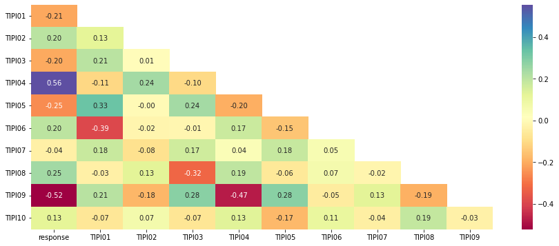

```python
#New Correlation Matrix

plt.figure(figsize=(15,6))

ax = plt.axes()
ax.set(facecolor = 'white')

corr = temp.corr().iloc[1:,:-1].copy()
mask = np.triu(np.ones_like(temp.corr(), dtype = np.bool))
mask = mask[1:,:-1]

sns.heatmap(corr, mask = mask, cmap = 'Spectral', annot = True, fmt = "0.2f")

plt.xticks(rotation = 0)
plt.yticks(rotation = 0)
plt.show()
```

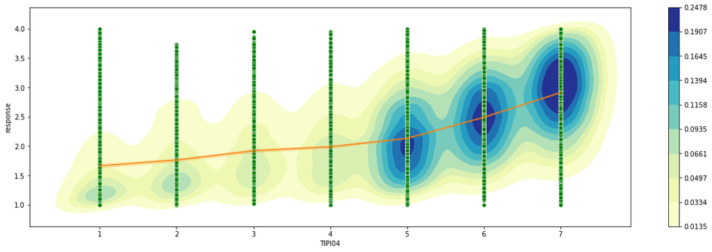

```python
#TIPI04 vs Response

plt.figure(figsize=(20,6))
sns.kdeplot(x = temp['TIPI04'], y = temp['response'], shade = True, cmap='YlGnBu', clip = (0,230000), cbar = True)
sns.scatterplot(data=temp, x='TIPI04', y='response', color = 'green')
sns.lineplot(x='TIPI04', y='response', data=temp)
plt.show()
```

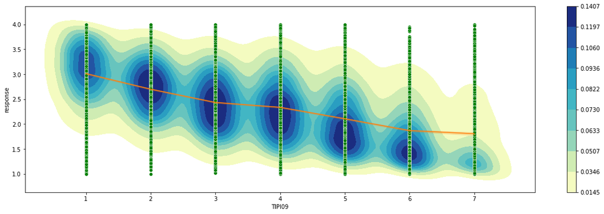

```python
#TIPI09 vs Response

plt.figure(figsize=(20,6))
sns.kdeplot(x = temp['TIPI09'], y = temp['response'], shade = True, cmap='YlGnBu', clip = (0,230000), cbar = True)
sns.scatterplot(data=temp, x='TIPI09', y='response', color = 'green')
sns.lineplot(x='TIPI09', y='response', dashes = True, data=temp)
plt.show()
```

## ANOVA Test

```python
from bioinfokit.analys import stat
```

```python
res = stat()
res.anova_stat(df=tipi, res_var='response', anova_model='response~C(TIPI04)+C(TIPI09)+C(TIPI04):C(TIPI09)')
res.anova_summary
```

|  | df | sum_sq | mean_sq | F | PR(>F) |
| --- | --- | --- | --- | --- | --- |
| C(TIPI04) | 7.0 | 2531.707968 | 361.672567 | 1292.798328 | 0.000000e+00 |
| C(TIPI09) | 7.0 | 1362.751035 | 194.678719 | 695.878941 | 0.000000e+00 |
| C(TIPI04):C(TIPI09) | 49.0 | 164.924166 | 3.365799 | 12.031047 | 7.263799e-93 |
| Residual | 34877.0 | 9757.170812 | 0.279759 | NaN | NaN |

# Demographic Data

## Creating a Table for Demographic Factors

```python
demography = dataset.iloc[:, 141:158]
demography.insert(0, 'response', qr.values)
demography
```

|  | response | education | urban | gender | engnat | age | screensize | uniquenetworklocation | hand | religion | orientation | race | voted | married | familysize | major | strike | age_group |
| --- | --- | --- | --- | --- | --- | --- | --- | --- | --- | --- | --- | --- | --- | --- | --- | --- | --- | --- |
| 0 | 3.404762 | 2 | 3 | 2 | 2 | 16.0 | 1 | 1 | 1 | 12 | 1 | 10 | 2 | 1 | 2 | 21 | 0 | below 20 |
| 1 | 2.619048 | 2 | 3 | 2 | 1 | 16.0 | 2 | 1 | 2 | 7 | 0 | 70 | 2 | 1 | 4 | 21 | 0 | below 20 |
| 2 | 2.619048 | 2 | 3 | 2 | 2 | 17.0 | 2 | 1 | 1 | 4 | 3 | 60 | 1 | 1 | 3 | 21 | 0 | below 20 |
| 3 | 2.166667 | 1 | 3 | 2 | 1 | 13.0 | 2 | 1 | 2 | 4 | 5 | 70 | 2 | 1 | 5 | biology | 0 | below 20 |
| 4 | 3.404762 | 3 | 2 | 2 | 2 | 19.0 | 2 | 2 | 3 | 10 | 1 | 10 | 2 | 1 | 4 | Psychology | 0 | below 20 |
| ... | ... | ... | ... | ... | ... | ... | ... | ... | ... | ... | ... | ... | ... | ... | ... | ... | ... | ... |
| 39768 | 2.571429 | 1 | 2 | 2 | 1 | 16.0 | 2 | 1 | 1 | 1 | 1 | 70 | 2 | 1 | 3 | 21 | 0 | below 20 |
| 39770 | 3.523810 | 3 | 2 | 1 | 2 | 21.0 | 1 | 1 | 1 | 10 | 0 | 10 | 2 | 1 | 4 | Mathematic | 1 | 20 to 24 |
| 39771 | 1.238095 | 3 | 2 | 2 | 1 | 48.0 | 2 | 1 | 1 | 7 | 1 | 30 | 1 | 2 | 3 | Computer Science | 0 | 40 to 49 |
| 39772 | 2.476190 | 3 | 2 | 2 | 1 | 20.0 | 2 | 1 | 1 | 6 | 1 | 60 | 1 | 1 | 2 | History | 0 | 20 to 24 |
| 39773 | 2.261905 | 3 | 3 | 2 | 2 | 26.0 | 1 | 1 | 1 | 10 | 1 | 10 | 1 | 1 | 4 | Cognitive Science | 0 | 25 to 29 |

34941 rows × 18 columns

```python
#Removing Irrelevant Columns
demography.drop(['age','strike'],axis = 1,inplace=True)

#Removing data with empty response
demography = demography[(demography['age_group'] != 0) & (demography['education'] != 0) & (demography['engnat'] != 0) & (demography['familysize'] != 0) & (demography['gender'] != 0) & (demography['hand'] != 0) & (demography['major'] != 0) & (demography['married'] != 0) & (demography['orientation'] != 0) & (demography['race'] != 0) & (demography['religion'] != 0) & (demography['screensize'] != 0) & (demography['uniquenetworklocation'] != 0) & (demography['urban'] != 0) & (demography['voted'] != 0)]
print('Rows: {}, Columns: {}'.format(demography.shape[0], demography.shape[1]))
```

[output not shown]

## Data Visualisation of Demographic Factors

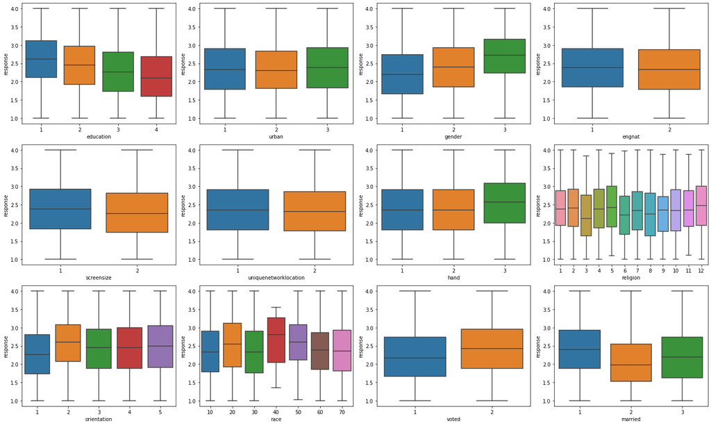

```python
#BOXPLOTS: Central Tendency of Categorical Attributes w.r.t Response

fig, axes = plt.subplots(3, 4, figsize=(20,12))
l = ['education', 'urban', 'gender', 'engnat', 'screensize', 'uniquenetworklocation', 'hand', 'religion',
       'orientation', 'race', 'voted', 'married', 'familysize']
for i, ax in enumerate(axes.ravel()):
    sns.boxplot(data=demography, y='response', x=l[i], ax=ax)
plt.tight_layout()
```

```python
#Function to convert Categorical data (age_group) to Ordinal data

def label_age(row):
    if row['age_group'] == 'below 20':
        return 1
    elif row['age_group'] == '20 to 24':
        return 2
    elif row['age_group'] == '25 to 29':
        return 3
    elif row['age_group'] == '30 to 34':
        return 4
    elif row['age_group'] == '35 to 39':
        return 5
    elif row['age_group'] == '40 to 49':
        return 6
    elif row['age_group'] == '50 to 59':
        return 7
    elif row['age_group'] == 'above 60':
        return 8

demography['age_group'] = demography.apply(lambda row: label_age(row), axis=1)
demography.head(2)
```

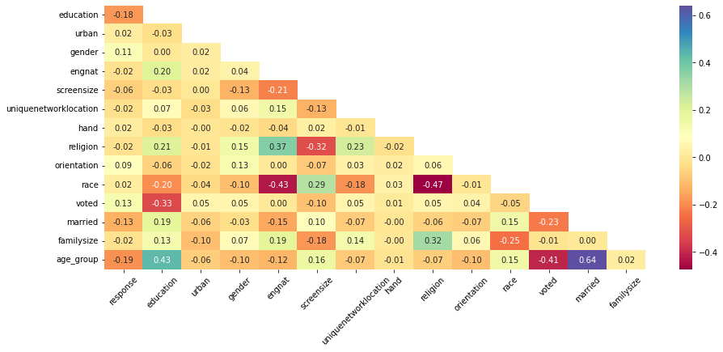

```python
#Correlation Matrix

plt.figure(figsize=(15,6))

ax = plt.axes()
ax.set(facecolor = 'white')

corr = demography.corr().iloc[1:,:-1].copy()
mask = np.triu(np.ones_like(demography.corr(), dtype = np.bool))
mask = mask[1:,:-1]

sns.heatmap(corr, mask = mask, cmap = 'Spectral', annot = True, fmt = "0.2f")

plt.xticks(rotation = 45)
plt.show()
```

A strong correlation exist between age_group and married which is quite understandable. But no such strong correlation of any demographic factors exists with 'response'.

## Descriptive Statistics of each factor

```python
#Function to calculate Descriptive Statistics of various Demographic Factors

def descrip(x):
  f = demography.groupby(x)
  l = list(enumerate(demography.columns))
  l = dict(l)
  for i in range(len(l)-1):
    if(l[i] != x):
      print(l[i].upper(),"vs",x.upper())
      print(f[l[i]].describe())
      print()
    else:
      pass
```

### AGE

```python
descrip('age_group')
```

```
RESPONSE vs AGE_GROUP
             count      mean       std  ...       50%       75%       max
age_group                               ...
1.0         9748.0  2.514242  0.686802  ...  2.523810  3.047619  4.000000
2.0        11468.0  2.373069  0.683161  ...  2.357143  2.880952  4.000000
3.0         4287.0  2.289258  0.698396  ...  2.261905  2.809524  4.000000
4.0         1735.0  2.160752  0.690651  ...  2.071429  2.666667  4.000000
5.0          916.0  2.101632  0.687410  ...  2.011905  2.619048  3.976190
6.0         1069.0  2.106419  0.697972  ...  2.023810  2.571429  4.000000
7.0          606.0  2.052962  0.673081  ...  1.952381  2.523810  3.904762
8.0          193.0  1.839872  0.569401  ...  1.714286  2.190476  3.547619

[8 rows x 8 columns]

EDUCATION vs AGE_GROUP
             count      mean       std  min  25%  50%  75%  max
age_group
1.0         9748.0  1.851662  0.615412  1.0  1.0  2.0  2.0  4.0
2.0        11468.0  2.774590  0.617774  1.0  2.0  3.0  3.0  4.0
3.0         4287.0  3.169349  0.686693  1.0  3.0  3.0  4.0  4.0
4.0         1735.0  3.146974  0.736870  1.0  3.0  3.0  4.0  4.0
5.0          916.0  3.013100  0.786389  1.0  2.0  3.0  4.0  4.0
6.0         1069.0  3.006548  0.807823  1.0  2.0  3.0  4.0  4.0
7.0          606.0  2.907591  0.855536  1.0  2.0  3.0  4.0  4.0
8.0          193.0  2.901554  0.826418  1.0  2.0  3.0  4.0  4.0

URBAN vs AGE_GROUP
             count      mean       std  min  25%  50%  75%  max
age_group
1.0         9748.0  2.322117  0.750264  1.0  2.0  2.0  3.0  3.0
2.0        11468.0  2.224712  0.782311  1.0  2.0  2.0  3.0  3.0
3.0         4287.0  2.206905  0.773372  1.0  2.0  2.0  3.0  3.0
4.0         1735.0  2.161960  0.782408  1.0  2.0  2.0  3.0  3.0
5.0          916.0  2.135371  0.801102  1.0  1.0  2.0  3.0  3.0
6.0         1069.0  2.186155  0.766794  1.0  2.0  2.0  3.0  3.0
7.0          606.0  2.150165  0.746712  1.0  2.0  2.0  3.0  3.0
8.0          193.0  2.082902  0.745380  1.0  2.0  2.0  3.0  3.0

GENDER vs AGE_GROUP
             count      mean       std  min  25%  50%  75%  max
```

[output cut: 126 more lines]

```
6.0         1069.0  3.153414  1.713802  1.0  2.0  3.0  4.0   12.0
7.0          606.0  3.547855  1.959133  1.0  2.0  3.0  4.0   13.0
8.0          193.0  3.212435  1.756373  1.0  2.0  3.0  4.0   11.0

MAJOR vs AGE_GROUP
             count  unique   top    freq
age_group
1.0         9748.0  1432.0  21.0  5043.0
2.0        11468.0  2538.0  21.0  1248.0
3.0         4287.0  1217.0  21.0   507.0
4.0         1735.0   594.0  21.0   292.0
5.0          916.0   364.0  21.0   220.0
6.0         1069.0   357.0  21.0   295.0
7.0          606.0   228.0  21.0   208.0
8.0          193.0    99.0  21.0    67.0
```

### URBAN

```python
descrip('urban')
```

```
RESPONSE vs URBAN
         count      mean       std  min       25%       50%       75%  max
urban
1       6189.0  2.363329  0.716302  1.0  1.785714  2.333333  2.904762  4.0
2      10354.0  2.336302  0.679405  1.0  1.809524  2.309524  2.833333  4.0
3      13511.0  2.390972  0.707678  1.0  1.833333  2.380952  2.928571  4.0

EDUCATION vs URBAN
         count      mean       std  min  25%  50%  75%  max
urban
1       6189.0  2.628211  0.802541  1.0  2.0  3.0  3.0  4.0
2      10354.0  2.556790  0.854481  1.0  2.0  3.0  3.0  4.0
3      13511.0  2.558952  0.835323  1.0  2.0  3.0  3.0  4.0

GENDER vs URBAN
         count      mean       std  min  25%  50%  75%  max
urban
1       6189.0  1.800776  0.427209  1.0  2.0  2.0  2.0  3.0
2      10354.0  1.748793  0.466973  1.0  1.0  2.0  2.0  3.0
3      13511.0  1.810525  0.421388  1.0  2.0  2.0  2.0  3.0

ENGNAT vs URBAN
         count      mean       std  min  25%  50%  75%  max
urban
1       6189.0  1.677331  0.467535  1.0  1.0  2.0  2.0  2.0
2      10354.0  1.597450  0.490435  1.0  1.0  2.0  2.0  2.0
3      13511.0  1.679816  0.466564  1.0  1.0  2.0  2.0  2.0

SCREENSIZE vs URBAN
         count      mean       std  min  25%  50%  75%  max
urban
1       6189.0  1.247051  0.431332  1.0  1.0  1.0  1.0  2.0
2      10354.0  1.303458  0.459773  1.0  1.0  1.0  2.0  2.0
3      13511.0  1.261787  0.439623  1.0  1.0  1.0  2.0  2.0

UNIQUENETWORKLOCATION vs URBAN
         count      mean       std  min  25%  50%  75%  max
urban
1       6189.0  1.233317  0.422977  1.0  1.0  1.0  1.0  2.0
2      10354.0  1.188430  0.391074  1.0  1.0  1.0  1.0  2.0
```

[output cut: 42 more lines]

```
3      13511.0  1.147139  0.417731  1.0  1.0  1.0  1.0  3.0

FAMILYSIZE vs URBAN
         count      mean       std  min  25%  50%  75%    max
urban
1       6189.0  4.074002  2.698132  1.0  2.0  4.0  5.0  133.0
2      10354.0  3.508982  1.741635  1.0  2.0  3.0  4.0   16.0
3      13511.0  3.467397  1.766021  1.0  2.0  3.0  4.0   54.0

MAJOR vs URBAN
         count  unique   top    freq
urban
1       6189.0  1487.0  21.0  1465.0
2      10354.0  2038.0  21.0  2880.0
3      13511.0  2510.0  21.0  3544.0
```

### GENDER

```python
descrip('gender')
```

```
RESPONSE vs GENDER
          count      mean       std  min       25%       50%       75%  max
gender
1        6782.0  2.229806  0.685148  1.0  1.672619  2.190476  2.738095  4.0
2       22884.0  2.401250  0.699468  1.0  1.857143  2.404762  2.928571  4.0
3         388.0  2.702013  0.644004  1.0  2.238095  2.726190  3.166667  4.0

EDUCATION vs GENDER
          count      mean       std  min  25%  50%  75%  max
gender
1        6782.0  2.531996  0.841744  1.0  2.0  2.0  3.0  4.0
2       22884.0  2.595045  0.828846  1.0  2.0  3.0  3.0  4.0
3         388.0  1.948454  0.875992  1.0  1.0  2.0  2.0  4.0

URBAN vs GENDER
          count      mean       std  min  25%  50%  75%  max
gender
1        6782.0  2.209083  0.741617  1.0  2.0  2.0  3.0  3.0
2       22884.0  2.254020  0.781186  1.0  2.0  2.0  3.0  3.0
3         388.0  2.234536  0.739539  1.0  2.0  2.0  3.0  3.0

ENGNAT vs GENDER
          count      mean       std  min  25%  50%  75%  max
gender
1        6782.0  1.587585  0.492305  1.0  1.0  2.0  2.0  2.0
2       22884.0  1.676411  0.467855  1.0  1.0  2.0  2.0  2.0
3         388.0  1.255155  0.436511  1.0  1.0  1.0  2.0  2.0

SCREENSIZE vs GENDER
          count      mean       std  min  25%  50%  75%  max
gender
1        6782.0  1.396933  0.489298  1.0  1.0  1.0  2.0  2.0
2       22884.0  1.232608  0.422504  1.0  1.0  1.0  1.0  2.0
3         388.0  1.497423  0.500639  1.0  1.0  1.0  2.0  2.0

UNIQUENETWORKLOCATION vs GENDER
          count      mean       std  min  25%  50%  75%  max
gender
1        6782.0  1.146417  0.353550  1.0  1.0  1.0  1.0  2.0
2       22884.0  1.218187  0.413024  1.0  1.0  1.0  1.0  2.0
```

[output cut: 42 more lines]

```
3         388.0  1.046392  0.264941  1.0  1.0  1.0  1.0  3.0

FAMILYSIZE vs GENDER
          count      mean       std  min  25%  50%  75%    max
gender
1        6782.0  3.284577  1.750504  1.0  2.0  3.0  4.0   21.0
2       22884.0  3.713162  1.874221  1.0  2.0  3.0  5.0   54.0
3         388.0  2.953608  6.822058  1.0  2.0  2.0  3.0  133.0

MAJOR vs GENDER
          count  unique   top    freq
gender
1        6782.0  1402.0  21.0  2124.0
2       22884.0  3645.0  21.0  5534.0
3         388.0   116.0  21.0   231.0
```

### VOTE

```python
descrip('voted')
```

```
RESPONSE vs VOTED
         count      mean       std  min       25%       50%       75%  max
voted
1       8663.0  2.224774  0.688875  1.0  1.666667  2.166667  2.738095  4.0
2      21391.0  2.423820  0.696701  1.0  1.880952  2.428571  2.952381  4.0

EDUCATION vs VOTED
         count      mean       std  min  25%  50%  75%  max
voted
1       8663.0  3.007965  0.723205  1.0  3.0  3.0  4.0  4.0
2      21391.0  2.396101  0.813538  1.0  2.0  2.0  3.0  4.0

URBAN vs VOTED
         count      mean       std  min  25%  50%  75%  max
voted
1       8663.0  2.184463  0.768764  1.0  2.0  2.0  3.0  3.0
2      21391.0  2.267589  0.772188  1.0  2.0  2.0  3.0  3.0

GENDER vs VOTED
         count      mean       std  min  25%  50%  75%  max
voted
1       8663.0  1.753665  0.456149  1.0  1.0  2.0  2.0  3.0
2      21391.0  1.800851  0.432094  1.0  2.0  2.0  2.0  3.0

ENGNAT vs VOTED
         count      mean       std  min  25%  50%  75%  max
voted
1       8663.0  1.647813  0.477680  1.0  1.0  2.0  2.0  2.0
2      21391.0  1.652190  0.476286  1.0  1.0  2.0  2.0  2.0

SCREENSIZE vs VOTED
         count      mean       std  min  25%  50%  75%  max
voted
1       8663.0  1.342029  0.474417  1.0  1.0  1.0  2.0  2.0
2      21391.0  1.245197  0.430214  1.0  1.0  1.0  1.0  2.0

UNIQUENETWORKLOCATION vs VOTED
         count      mean       std  min  25%  50%  75%  max
voted
1       8663.0  1.171419  0.376896  1.0  1.0  1.0  1.0  2.0
```

[output cut: 28 more lines]

```
voted
1       8663.0  1.330371  0.560626  1.0  1.0  1.0  2.0  3.0
2      21391.0  1.106166  0.369722  1.0  1.0  1.0  1.0  3.0

FAMILYSIZE vs VOTED
         count      mean       std  min  25%  50%  75%    max
voted
1       8663.0  3.653469  1.946636  1.0  2.0  3.0  5.0   15.0
2      21391.0  3.587677  2.021961  1.0  2.0  3.0  5.0  133.0

MAJOR vs VOTED
         count  unique   top    freq
voted
1       8663.0  2012.0  21.0  1276.0
2      21391.0  3277.0  21.0  6613.0
```

## ANOVA Test

```python
from bioinfokit.analys import stat
```

```python
res = stat()
res.anova_stat(df=demography, res_var='response', anova_model='response~C(age_group)+C(gender)+C(age_group):C(gender)')
res.anova_summary
```

|  | df | sum_sq | mean_sq | F | PR(>F) |
| --- | --- | --- | --- | --- | --- |
| C(age_group) | 7.0 | 503.098693 | 71.871242 | 154.056384 | 1.629332e-224 |
| C(gender) | 2.0 | 139.368543 | 69.684272 | 149.368602 | 2.824347e-65 |
| C(age_group):C(gender) | 14.0 | 21.826960 | 1.559069 | 3.341872 | 2.105611e-05 |
| Residual | 29998.0 | 13994.833966 | 0.466526 | NaN | NaN |

```python
res = stat()
res.anova_stat(df=demography, res_var='response', anova_model='response~C(age_group)+C(married)+C(age_group):C(married)')
res.anova_summary
```

|  | df | sum_sq | mean_sq | F | PR(>F) |
| --- | --- | --- | --- | --- | --- |
| C(age_group) | 7.0 | 268.166676 | 38.309525 | 81.567538 | 6.037740e-118 |
| C(married) | 2.0 | 54.266633 | 27.133317 | 57.771476 | 9.085778e-26 |
| C(age_group):C(married) | 14.0 | 12.712570 | 0.908041 | 1.933374 | 1.890818e-02 |
| Residual | 29998.0 | 14089.050267 | 0.469666 | NaN | NaN |

```python
res = stat()
res.anova_stat(df=demography, res_var='response', anova_model='response~C(age_group)+C(voted)+C(age_group):C(voted)')
res.anova_summary
```

|  | df | sum_sq | mean_sq | F | PR(>F) |
| --- | --- | --- | --- | --- | --- |
| C(age_group) | 7.0 | 355.280073 | 50.754296 | 107.930788 | 7.425361e-157 |
| C(voted) | 1.0 | 34.344761 | 34.344761 | 73.035336 | 1.332880e-17 |
| C(age_group):C(voted) | 7.0 | 11.406832 | 1.629547 | 3.465290 | 1.029910e-03 |
| Residual | 30006.0 | 14110.277877 | 0.470249 | NaN | NaN |